# Sample - Summary - Homework

Jose Rico

April 14, 2020

## Assignment Overview

This will be your summative assignment for the sampling unit. You will be;

- conducting a simulation (I have already done that for you)
- analyzing the simulations with statistics and visualizations
- constructing confidence intervals from sample statistics

## Assignment Scenario

We will be analyzing a particular game, the rolling of three dice. A winning rolls is when you get at least a match of two die faces. For example; 1,1,4 would be a winning roll. 1,2,3 would be a losing roll.

## Constructing a population data frame

Simulate rolling 100,000 times

```r
set.seed(1123581321)
roll1 = sample(1:6,100000, replace=T)
roll2 = sample(1:6,100000, replace=T)
roll3 = sample(1:6,100000, replace=T)
roll_sim_population <- data.frame(roll1, roll2, roll3) %>%
  mutate(win = if_else(roll1==roll2 | roll1==roll3 | roll2==roll3, TRUE, FALSE))
```

## Assignment Tasks

### Sampling/Analysis/Narratives for different sample sizes

1. Take 1000 samples for sample size 25
2. Construct sampling distributions histograms for sample size of 25.
3. Calculate (and Table) sampling distributions statistics for each sample size. (mean, sd, 2.5th and 97.5th percentiles)

#### Sample Size of 25

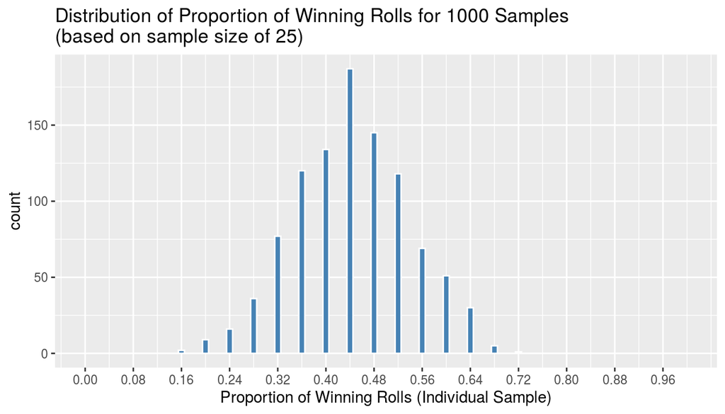

#### Sample Size of 100

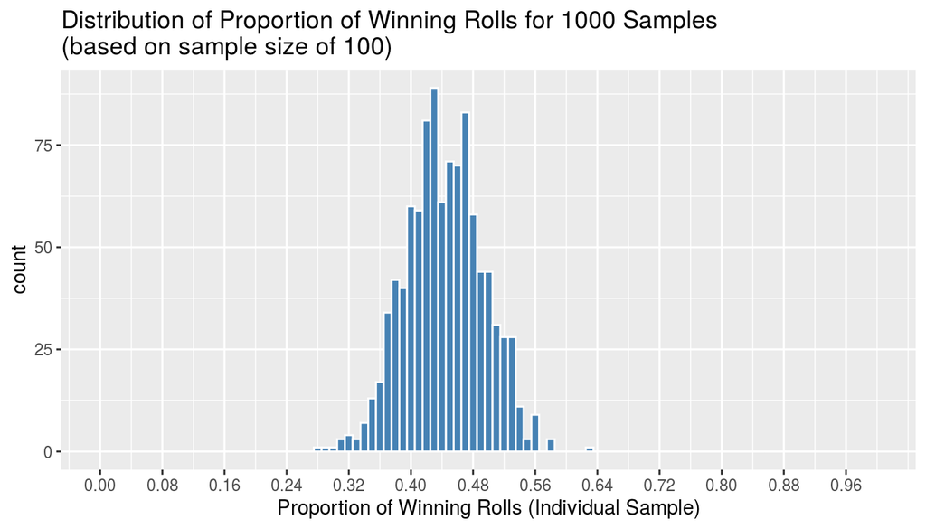

#### Sample Size of 400

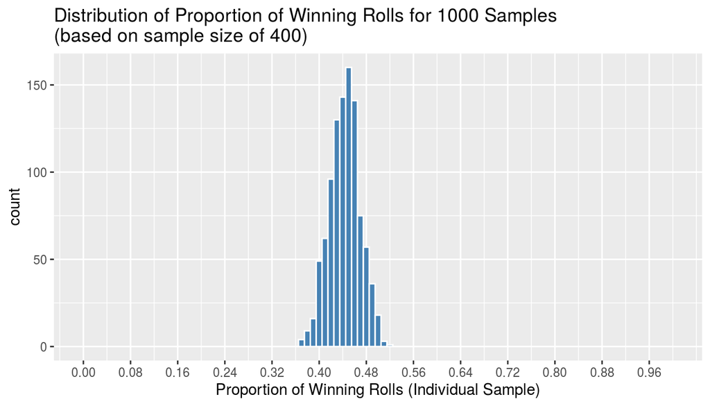

| sample size | mean | sd | bottom_2.5 | top_2.5 |
| --- | --- | --- | --- | --- |
| 25 | 0.44328 | 0.096 | 0.24 | 0.64 |
| 100 | 0.44335 | 0.05 | 0.35 | 0.54 |
| 400 | 0.444865 | 0.026 | 0.395 | 0.495 |

n=25

| win | prop_win | se | me | lower | upper |
| --- | --- | --- | --- | --- | --- |
| 11 | 0.44 | 0.0992774 | 0.1945801 | 0.2454199 | 0.6345801 |

n= 100

| win | prop_win | se | me | lower | upper |
| --- | --- | --- | --- | --- | --- |
| 42 | 0.42 | 0.0493559 | 0.0967357 | 0.3232643 | 0.5167357 |

n= 400

| win | prop_win | se | me | lower | upper |
| --- | --- | --- | --- | --- | --- |
| 178 | 0.445 | 0.0248483 | 0.0487018 | 0.3962982 | 0.4937018 |

```r
ab <- 12
cd <- 24
ef <- 36
```

[output not shown]